# Análisis Estadístico de Eficiencia y Letalidad Hospitalaria

Evaluación comparativa: Sector Público vs. Privado (Ecuador 2024)

Departamento de Ciencia de Datos - UNACH

2026-01-25

# 1 Introducción

El presente informe expone los resultados del análisis estadístico inferencial aplicado a la base de datos de Egresos Hospitalarios 2024. El objetivo es validar, mediante pruebas de hipótesis y cálculo de probabilidades, si existen discrepancias estructurales en la gestión sanitaria entre los sectores público y privado.

El análisis se estructura en tres componentes metodológicos:

1. **Análisis Descriptivo:** Medidas de tendencia central sobre la estancia hospitalaria.
2. **Probabilidad Condicional:** Estimación del riesgo relativo de mortalidad.
3. **Inferencia Estadística:** Prueba t-Student de Welch para diferencia de medias.

# 2 Metodología 1: Análisis de Eficiencia Operativa

Se evalúa la variable **Días de Estada** como indicador de eficiencia en la gestión de camas.

## 2.1 Estadísticos Descriptivos

La Tabla 1 resume el comportamiento de la estancia hospitalaria. Se observa una diferencia notable en los tiempos de gestión.

Tabla 1: Comparativa de Tiempos de Estancia

| Sector | N (Casos) | Media (Días) | Mediana | Desv. Estándar | Coef. Var (%) |
| --- | --- | --- | --- | --- | --- |
| Privado | 389262 | 3.41 | 1 | 8.64 | 253.76 |
| Público | 743328 | 4.94 | 3 | 7.09 | 143.53 |

## 2.2 Visualización de la Distribución

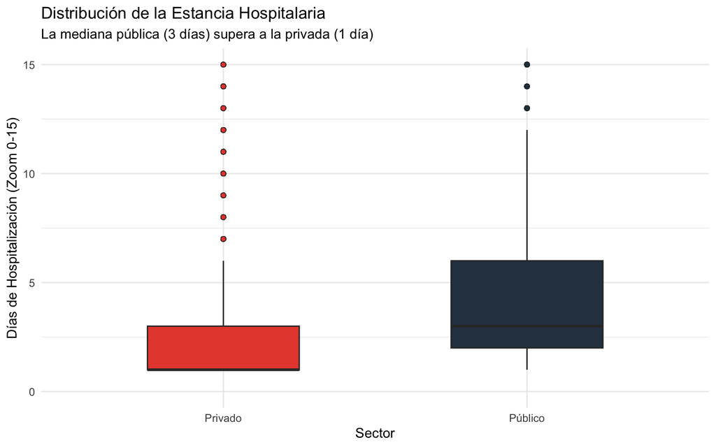

**Interpretación de Resultados:**

- **Brecha de Medias:** El sector público presenta una estancia media de **4.94 días**, frente a **3.41 días** del sector privado. Esta diferencia de ~1.5 días implica una rotación de camas significativamente más lenta en la red pública.
- **Variabilidad (CV):** El sector privado muestra un Coeficiente de Variación extremadamente alto (**253%**). Esto indica una alta heterogeneidad: atiende mayoritariamente procedimientos muy cortos (Mediana = 1), pero mantiene casos específicos de larga estancia que inflan la desviación.

# 3 Metodología 2: Análisis de Letalidad (Probabilidad)

Tabla 2: Probabilidad Condicional de Letalidad

| tipo_gestion | Fallecidos | Probabilidad |
| --- | --- | --- |
| Privado | 4873 | 1.25% |
| Público | 12830 | 1.73% |

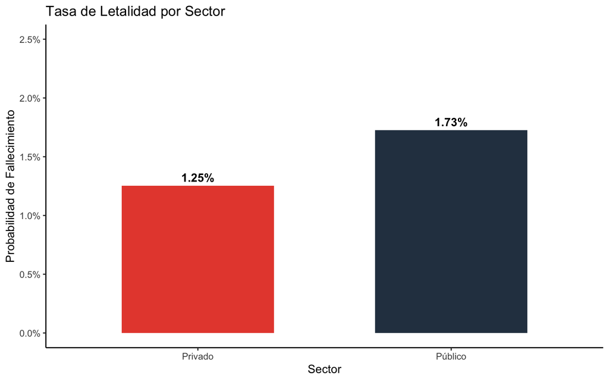

**Hallazgo - Riesgo Relativo:** El cálculo arroja un **Riesgo Relativo (RR) de 1.38**. Esto significa que, basándonos en los datos crudos, es **1.38 veces más probable** que un egreso termine en fallecimiento en el sector público comparado con el privado.

*Nota Técnica:* Este indicador no aísla la complejidad del paciente (Gravedad CIE-10), factor que suele ser mayor en hospitales de referencia pública.

# 4 Metodología 3: Inferencia Estadística (Prueba de Hipótesis)

Para determinar si la diferencia observada en la estancia media (4.94 vs 3.41) es estadísticamente significativa o producto del azar, se aplica la prueba **t-Student de Welch**.

- **Hipótesis nula (H₀):** $\mu_{\text{público}} = \mu_{\text{privado}}$ *(Las medias son iguales)*
- **Hipótesis alternativa (H₁):** $\mu_{\text{público}} \neq \mu_{\text{privado}}$ *(Las medias son diferentes)*

Tabla 3: Resultados de la Prueba t-Student de Welch

| Diferencia Estimada | Estadístico t | P-Valor | IC Inf | IC Sup |
| --- | --- | --- | --- | --- |
| -1.5322 | -95.1147 | 0 | -1.5637 | -1.5006 |

# 5 Conclusiones Generales

- **Inequidad en Tiempos de Atención:**  
  Existe evidencia estadística robusta ($p < 2.2e^{-16}$) para afirmar que el sector público mantiene a los pacientes hospitalizados, en promedio, **1.5 días más** que el sector privado. Esto sugiere diferencias en protocolos de alta, burocracia administrativa o tiempos de recuperación.
- **Disparidad en Resultados Clínicos:**  
  La tasa de letalidad del sector público (**1.73%**) supera a la del privado (**1.25%**).
- **Variabilidad Operativa:**  
  El sector privado, aunque más rápido en mediana (**1 día**), presenta una variabilidad extrema ($CV > 250\%$), lo que indica una operatividad dual: alta rotación en procedimientos electivos y estancias prolongadas selectivas.